# hw2

1. Dice Game
   1. Game Implementations
      1. Version 1

         ::: {.cell}

         ```r
         #' Dice Game V1
         #'
         #' @param num_dice number of dice to roll
         #' @return net profit
         dice_game_v1 <- function(num_dice){
             net_profit <- 0
             for (i in 1:num_dice){
                 die_roll <- sample(1:6, 1)
                 if (die_roll %in% c(2,4,6)){
                 net_profit <- net_profit + 2
                 } else {
                 net_profit <- net_profit - 2
                 }
             }
             return(net_profit)
         }
         ```

         :::
      2. Version 2

         ::: {.cell}

         ```r
         #' Dice Game V2
         #'
         #' @param num_dice number of dice to roll
         #' @return net profit
         dice_game_v2 <- function(num_dice){
             die_rolls <- sample(1:6, num_dice, replace = TRUE)
             net_profit <- sum(ifelse(die_rolls %in% c(2,4,6), 2, -2))
             return(net_profit)
         }
         ```

         :::
      3. Version 3

         ::: {.cell}

         ```r
         #' Dice Game V3
         #'
         #' @param num_dice number of dice to roll
         #' @return net profit
         dice_game_v3 <- function(num_dice) {
             die_rolls <- sample(1:6, num_dice, replace = TRUE)  # Simulate dice rolls
             roll_counts <- table(die_rolls)  # Count the occurrences of each roll

             # Ensure all possible outcomes (1 to 6) have counts, replace missing ones with 0
             roll_counts <- ifelse(!1:6 %in% names(roll_counts), 0, roll_counts)

             # Calculate net profit based on the counts using table()
             net_profit <- (roll_counts[2] + roll_counts[4] + roll_counts[6]) * 2
             net_profit <- net_profit - (roll_counts[1] + roll_counts[3] + roll_counts[5]) * 2

             return(net_profit)
         }
         ```

         :::
      4. Version 4 (Implement this game by using one of the “apply” functions.)

         ::: {.cell}

         ```r
         #' Dice Game V4
         #'
         #' @param num_dice number of dice to roll
         #' @return net profit
         dice_game_v4 <- function(num_dice) {
             die_rolls <- sample(1:6, num_dice, replace = TRUE)  # Simulate dice rolls

             # Define a function to calculate profit/loss for a single roll
             calculate_profit <- function(roll) {
                 if (roll %in% c(2, 4, 6)) {
                 return(2)
                 } else {
                 return(-2)
                 }
             }

             # Use sapply to apply the calculate_profit function to each roll
             profits <- sapply(die_rolls, calculate_profit)

             # Calculate the total net profit by summing up the profits
             net_profit <- sum(profits)

             return(net_profit)
         }
         ```

         :::
   2. Verfiy
      1. Version 1

         ::: {.cell}

         ```r
         num_dice <- 3
         print(dice_game_v1(num_dice))
         ```

         ::: {.cell-output .cell-output-stdout} `[1] -2` :::

         ```r
         num_dice <- 3000
         print(dice_game_v1(num_dice))
         ```

         ::: {.cell-output .cell-output-stdout} `[1] -128` ::: :::
      2. Version 2

         ::: {.cell}

         ```r
         num_dice <- 3
         print(dice_game_v2(num_dice))
         ```

         ::: {.cell-output .cell-output-stdout} `[1] -2` :::

         ```r
         num_dice <- 3000
         print(dice_game_v2(num_dice))
         ```

         ::: {.cell-output .cell-output-stdout} `[1] -32` ::: :::
      3. Version 3

         ::: {.cell}

         ```r
         num_dice <- 3
         print(dice_game_v3(num_dice))
         ```

         ::: {.cell-output .cell-output-stdout} `[1] 2` :::

         ```r
         num_dice <- 3000
         print(dice_game_v3(num_dice))
         ```

         ::: {.cell-output .cell-output-stdout} `[1] 96` ::: :::
      4. Version 4

         ::: {.cell}

         ```r
         num_dice <- 3
         print(dice_game_v4(num_dice))
         ```

         ::: {.cell-output .cell-output-stdout} `[1] -6` :::

         ```r
         num_dice <- 3000
         print(dice_game_v4(num_dice))
         ```

         ::: {.cell-output .cell-output-stdout} `[1] -36` ::: :::
   3. Same Results
      1. Version 1

         ::: {.cell}

         ```r
         set.seed(1234)
         num_dice <- 3
         print(dice_game_v1(num_dice))
         ```

         ::: {.cell-output .cell-output-stdout} `[1] 6` :::

         ```r
         num_dice <- 3000
         print(dice_game_v1(num_dice))
         ```

         ::: {.cell-output .cell-output-stdout} `[1] -28` ::: :::
      2. Version 2

         ::: {.cell}

         ```r
         set.seed(1234)
         num_dice <- 3
         print(dice_game_v2(num_dice))
         ```

         ::: {.cell-output .cell-output-stdout} `[1] 6` :::

         ```r
         num_dice <- 3000
         print(dice_game_v2(num_dice))
         ```

         ::: {.cell-output .cell-output-stdout} `[1] -28` ::: :::
      3. Version 3

         ::: {.cell}

         ```r
         set.seed(1234)
         num_dice <- 3
         print(dice_game_v3(num_dice))
         ```

         ::: {.cell-output .cell-output-stdout} `[1] 6` :::

         ```r
         num_dice <- 3000
         print(dice_game_v3(num_dice))
         ```

         ::: {.cell-output .cell-output-stdout} `[1] -28` ::: :::
      4. Version 4

         ::: {.cell}

         ```r
         set.seed(1234)
         num_dice <- 3
         print(dice_game_v4(num_dice))
         ```

         ::: {.cell-output .cell-output-stdout} `[1] 6` :::

         ```r
         num_dice <- 3000
         print(dice_game_v4(num_dice))
         ```

         ::: {.cell-output .cell-output-stdout} `[1] -28` ::: :::
   4. Benchmark
      1. Version 1

         ::: {.cell}

         ```r
         library(microbenchmark)
         num_dice <- 100
         microbenchmark(dice_game_v1(num_dice))
         ```

         ::: {.cell-output .cell-output-stderr} `Warning in microbenchmark(dice_game_v1(num_dice)): less accurate nanosecond times to avoid potential integer overflows` :::

         ::: {.cell-output .cell-output-stdout} `Unit: microseconds expr min lq mean median uq max dice_game_v1(num_dice) 314.101 336.1795 367.916 342.8215 351.493 2690.174 neval 100` :::

         ```r
         num_dice <- 10000
         microbenchmark(dice_game_v1(num_dice))
         ```

         ::: {.cell-output .cell-output-stdout} `Unit: milliseconds expr min lq mean median uq max dice_game_v1(num_dice) 34.8138 35.82193 37.33484 36.6952 37.75081 58.16986 neval 100` ::: :::
      2. Version 2

         ::: {.cell}

         ```r
         library(microbenchmark)
         num_dice <- 100
         microbenchmark(dice_game_v2(num_dice))
         ```

         ::: {.cell-output .cell-output-stdout} `Unit: microseconds expr min lq mean median uq max neval dice_game_v2(num_dice) 11.316 12.136 13.63824 12.915 14.391 33.497 100` :::

         ```r
         num_dice <- 10000
         microbenchmark(dice_game_v2(num_dice))
         ```

         ::: {.cell-output .cell-output-stdout} `Unit: microseconds expr min lq mean median uq max dice_game_v2(num_dice) 570.884 588.924 639.9719 601.347 612.1505 4360.309 neval 100` ::: :::
      3. Version 3

         ::: {.cell}

         ```r
         library(microbenchmark)
         num_dice <- 100
         microbenchmark(dice_game_v3(num_dice))
         ```

         ::: {.cell-output .cell-output-stdout} `Unit: microseconds expr min lq mean median uq max neval dice_game_v3(num_dice) 40.918 43.1935 50.94209 44.2595 49.61 199.137 100` :::

         ```r
         num_dice <- 10000
         microbenchmark(dice_game_v3(num_dice))
         ```

         ::: {.cell-output .cell-output-stdout} `Unit: microseconds expr min lq mean median uq max neval dice_game_v3(num_dice) 566.005 622.544 726.914 644.561 677.607 7995.902 100` ::: :::
      4. Version 4

         ::: {.cell}

         ```r
         library(microbenchmark)
         num_dice <- 100
         microbenchmark(dice_game_v4(num_dice))
         ```

         ::: {.cell-output .cell-output-stdout} `Unit: microseconds expr min lq mean median uq max neval dice_game_v4(num_dice) 79.171 85.8745 92.93921 90.897 97.662 147.6 100` :::

         ```r
         num_dice <- 10000
         microbenchmark(dice_game_v4(num_dice))
         ```

         ::: {.cell-output .cell-output-stdout} `Unit: milliseconds expr min lq mean median uq max dice_game_v4(num_dice) 7.759742 7.963266 9.669639 9.277624 10.10988 23.18907 neval 100` ::: :::
   5. Monte Carlo Simulation

      ::: {.cell}

      ```r
      num_dice <- 10000
      num_sims <- 10000
      set.seed(1234)
      results <- replicate(num_sims, dice_game_v2(num_dice))
      print(mean(results))
      ```

      ::: {.cell-output .cell-output-stdout} `[1] 0.3376` ::: :::

      This seems to be a fair game because the average net profit is close to 0 over 10000 simulations of 10000 dice rolls.
2. Linear Regression
   1. Renaming - Modified CSV headers in place locally
   2. Restrict to “Gasoline”

      ::: {.cell}

      ```r
      cars <- read.csv("cars.csv")
      cars <- cars[cars$Fuel_Type == "Gasoline",]
      cars$Year <- as.factor(cars$Year)
      ```

      :::
   3. Fit Linear Regression for “Highway MPG”

      ::: {.cell}

      ```r
      model <- lm(
          Highway_MPG
          ~ Horsepower
          + Torque
          + Height
          + Width
          + Length
          + Year
          , data = cars
      )
      print(coefficients(model)[2])
      ```

      ::: {.cell-output .cell-output-stdout} `Horsepower 0.01635563` ::: :::

      The coeffecient for Horsepower is approximately 0.016. This means that for every 1 unit increase in Horsepower, Highway MPG increases by 0.016. The coeffecient is so low that it is almost negligible. This means that Horsepower has almost no effect on Highway MPG.
   4. Horsepower and Torque Interaction Plot

      ::: {.cell}

      ```r
      library(interactions)
      model <- lm(
          Highway_MPG
          ~ Horsepower * Torque
          + Height
          + Width
          + Length
          + Year
          , data = cars
      )
      interact_plot(model, pred = Horsepower, modx = Torque, data = cars)
      ```

      ::: {.cell-output-display}

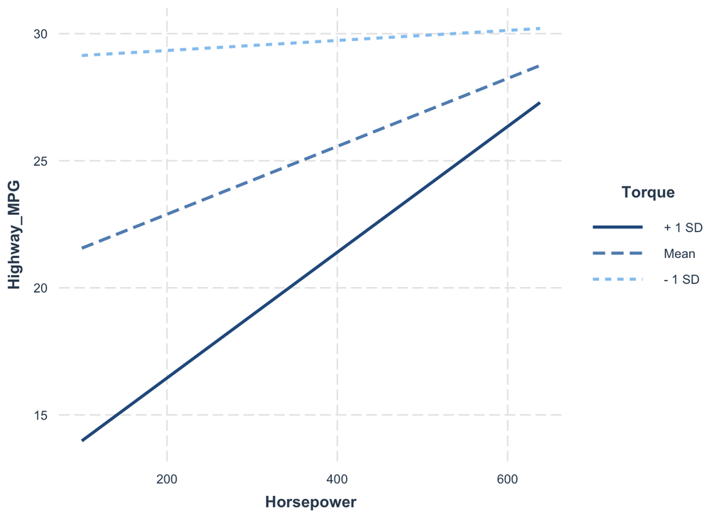

      ::: :::

      For lower torque values, we see the lowest amount of increase in Highway MPG as Horsepower increases. For higher torque values, we see the largest amount of increase in Highway MPG as Horsepower increases.
   5. Manually Calculate Coefficients

      ::: {.cell}

      ```r
      x <- model.matrix(model)
      x_t <- t(x)
      y <- cars$Highway_MPG
      b_hat <- solve(x_t %*% x) %*% x_t %*% y
      print(b_hat[, 1])
      ```

      ::: {.cell-output .cell-output-stdout} `(Intercept) Horsepower Torque Height 42.1879478687 -0.0166633227 -0.0860592704 0.0065603903 Width Length Year2010 Year2011 -0.0011694485 0.0017767232 -0.5627857770 0.0725356431 Year2012 Horsepower:Torque 1.1970329986 0.0001123567` :::

      ```r
      print(coefficients(model))
      ```

      ::: {.cell-output .cell-output-stdout} `(Intercept) Horsepower Torque Height 42.1879478687 -0.0166633227 -0.0860592704 0.0065603903 Width Length Year2010 Year2011 -0.0011694485 0.0017767232 -0.5627857770 0.0725356431 Year2012 Horsepower:Torque 1.1970329986 0.0001123567` ::: :::

      The coefficients are the same as the ones calculated by lm
3. Linear Regression
   1. Renaming - Modified CSV headers in place locally
   2. Restrict to “Gasoline”

      ::: {.cell}

      ```stata
      import delimited "cars.csv"
      (encoding automatically selected: ISO-8859-1)
      (18 vars, 5,076 obs)

      keep if fuel_type == "Gasoline"
      (485 observations deleted)
      ```

      :::
   3. Fit Linear Regression for “Highway MPG” (output truncated for display reasons)

      ::: {.cell}

      ```stata
      gen model_year_numeric = .
      (4,591 missing values generated)

      regress highway_mpg horsepower torque height width length i.year
            Source |       SS           df       MS      Number of obs   =     4,591
      -------------+----------------------------------   F(8, 4582)      =    413.35
             Model |  70043.6695         8  8755.45869   Prob > F        =    0.0000
          Residual |   97055.298     4,582  21.1818634   R-squared       =    0.4192
      -------------+----------------------------------   Adj R-squared   =    0.4182
             Total |  167098.968     4,590  36.4050038   Root MSE        =    4.6024

      ------------------------------------------------------------------------------
        highway_mpg | Coefficient  Std. err.      t    P>|t|     [95% conf. interval]
      --------------+----------------------------------------------------------------
         horsepower |   .0163556   .0022772     7.18   0.000     .0118913      .02082
             torque |  -.0507425    .002203   -23.03   0.000    -.0550614   -.0464236
             height |   .0099079   .0011267     8.79   0.000      .007699    .0121168
              width |  -.0003343   .0009045    -0.37   0.712    -.0021075    .0014388
             length |    .001729   .0008836     1.96   0.050    -3.36e-06    .0034613
                    |
               year |
              2010  |  -.4539681   .6768246    -0.67   0.502     -1.78087    .8729342
              2011  |   .1711016   .6757043     0.25   0.800    -1.153604    1.495808
              2012  |   1.302928   .6810076     1.91   0.056    -.0321751    2.638031
                    |
              _cons |   32.29266   .7225982    44.69   0.000     30.87602     33.7093
      -------------------------------------------------------------------------------
      ```

      :::

      Same answer as above. Coeffecient is approximately 0.016. This means that for every 1 unit increase in Horsepower, Highway MPG increases by 0.016.
   4. Horsepower and Torque Interaction Plot

      ::: {.cell}

      ```stata
      regress highway_mpg c.horsepower##c.torque height width length i.year

          Source   |       SS           df       MS      Number of obs   =     4,591
      -------------+----------------------------------   F(9, 4581)      =    480.07
             Model |  81105.8715         9  9011.76351   Prob > F        =    0.0000
          Residual |   85993.096     4,581  18.7716865   R-squared       =    0.4854
      -------------+----------------------------------   Adj R-squared   =    0.4844
             Total |  167098.968     4,590  36.4050038   Root MSE        =    4.3326

      -------------------------------------------------------------------------------
        highway_mpg | Coefficient  Std. err.      t    P>|t|     [95% conf. interval]
      --------------+----------------------------------------------------------------
         horsepower |  -.0166633   .0025388    -6.56   0.000    -.0216406    -.011686
             torque |  -.0860593   .0025333   -33.97   0.000    -.0910257   -.0810928
                    |
       c.horsepower#|
           c.torque |   .0001124   4.63e-06    24.28   0.000     .0001033    .0001214
                    |
             height |   .0065604   .0010696     6.13   0.000     .0044634    .0086573
              width |  -.0011694   .0008521    -1.37   0.170      -.00284    .0005011
             length |   .0017767   .0008318     2.14   0.033     .0001459    .0034075
                    |
               year |
              2010  |  -.5627858   .6371716    -0.88   0.377    -1.811949    .6863777
              2011  |   .0725356   .6361142     0.11   0.909    -1.174555    1.319626
              2012  |   1.197033   .6411085     1.87   0.062    -.0598488    2.453915
                    |
              _cons |   42.18795   .7930274    53.20   0.000     40.63323    43.74266
      -------------------------------------------------------------------------------
      margins, at(torque=(166 267 368)) over(horsepower)
      marginsplot, xdim(horsepower)
      ```

      :::

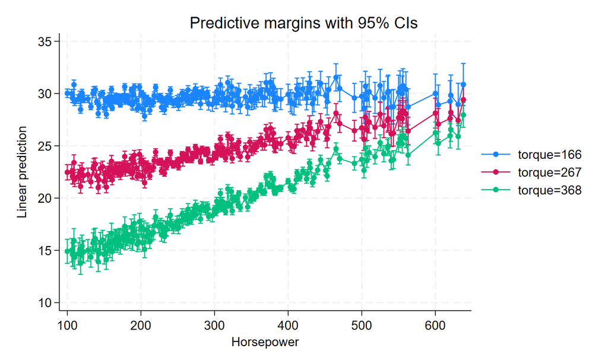

      Same answer as above for graph. For lower torque values, we see the lowest amount of increase in Highway MPG as Horsepower increases. For higher torque values, we see the largest amount of increase in Highway MPG as Horsepower increases.